# Mi Primer Mapa con R

Duberli E. Gonzáles

2 de marzo de 2019

Vamos a constuir nuestro Primer Mapa utilizando R.

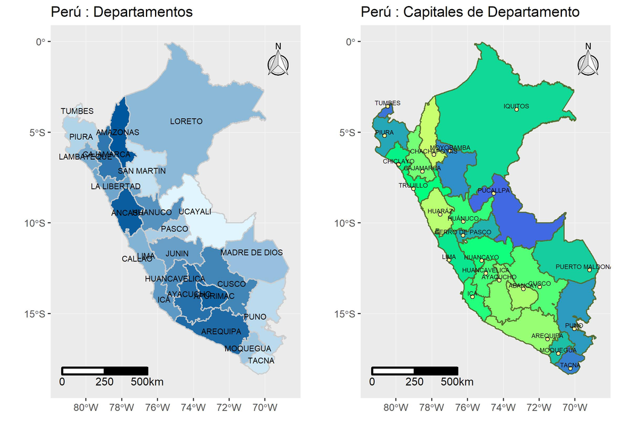

# 1 Presentación

Este es un tutorial en el que se muestra paso a paso la elaboración de un Mapa utilizando R. Este tutorial utiliza datos en formato *Shapefile* (.shp) de los límites y las capitales departamentales del Perú. Los archivos *Shapefile* de los límites departamentales, provinciales y distritales a escala 1:100,000 se encuentran disponibles de manera gratuita en la sección Descargas de la página web del **Instituto Geográfico Nacional** (http://www.idep.gob.pe/). Varios geoportales de instituciones públicas del Perú disponibilizan de manera gratuita las bases de datos cartográficas del país. El sitio web https://www.geogpsperu.com/ disponibiliza algunas de estas bases de datos, las cuales deben ser utilizadas bajo su propia responsabilidad.

Si bien se detalla paso a paso todo el procedimiento a seguir para elaborar un mapa utilizando R, ejecutar este tutorial requiere de conocimientos intermedios de R y Sistemas de Informaciones Geográficas (GIS). El presente tutorial puede ser reproducido utilizando el IDE RStudio y la versión 3.5.2 de R.

Comenzamos!

# 2 Base de datos

Si bien el mapa que aquí se presenta corresponde a la división política departamental del país con sus respectivas capitales departamentales, este tutotial se puede reproducir utilizando cualquier base de datos en formato *Shapefile*.

# 3 Paso 1

## 3.1 Directorio de Trabajo

En su explorador de windows cree una carpeta de trabajo matriz (ej. D:/GIS_con_R) y dentro de ella otra carpeta (ej. G:/GIS_con_R/SHP) en la que deberá guardar los archivos en formato *Shapefile* con los que decida trabajar.

## 3.2 Crear un nuevo proyecto de R

Ejecute RStudio. En la pantalla principal de RStudio, seleccione **File/New Project** en el menú principal, seguidamente seleccione la opción **Existing Directory**. Haciendo click en el ícono **Browse** dirijase a la carpeta de trabajo matriz, selecionela y haga click en **Open**; finalmente haga click en **Create Project**.

Si todo va bien, en su carpeta de trabajo matriz debería haberse creado un archivo con el mismo nombre de dicha carpeta y la extensión **.RProj** (ej. D:/GIS_con_R/GIS_con_R.Rproj). La creacción de este archivo permite que toda la información que trabajará se almacene en la carpeta matriz anteriormente creada.

## 3.3 Crear un nuevo Script R

A coninuación, cree un nuevo Script en el que escribirá el cógido R necesario para la elaboración de su primer mapa utilizando R. Para ello dirijase a **File/New File/R Script**; seleccione la opción **Save** en el menú **File** o haga click en el ícono **Save current document** y guarde el Script. Note que es direccionado de manera automática a la carpeta matriz de trabajo.

# 4 Paso 2

## 4.1 Bibliotecas

R utiliza diferentes bibliotecas para realizar el procesamiento de diversos tipos de datos. Elaborar un mapa en R requerirá entonces cargar las bibliotecas necesarias para ello. En este tutorial utilizaremos las bibliotecas `dplyr`, `ggplot2` y `sf`, las cuales deberán estar previamente instaladas en su computador. Para cargar las bibliotecas utilice la función `library()`.

```r
library(dplyr)
library(ggplot2)
library(sf)
library(ggsn)
```

**Importante**: Recuerde que puede instalar una biblioteca utilizando la función `install.packages()` escribiendo dentro del paréntesis el nombre del paquete entre comillas - ej. `install.packages('dplyr')` - para ello requiere estar conectado a una red de internet.

# 5 Paso 3

Ahora se encuentra listo para empezar a trabajar con la base de datos GIS.

## 5.1 Lectura de Datos

Para acceder a la base de datos, es decir a los archivos *Shapefile* utilice la función `st_read()` del paquete `sf`, el cual permite trabajar con datos vectoriales espaciales.

Para leer el archivo *Shapefile* de los departamentos del Perú, escriba y ejecute el siguiente código:

```r
peru <- st_read('./SHP/departamentos.shp')
```

Para leer el archivo de las capitales departamentales, escriba y ejecute:

```r
cap_dep <- st_read('./SHP/Cap_Dep.shp')
```

## 5.2 Explorar la base de datos

Las funciones `st_geometry_type()`, `st_crs()` y `st_bbox` pueden ser utilizadas para explorar la base de datos con las que se está trabajando

```r
st_geometry_type(peru)
```

```
##  [1] MULTIPOLYGON MULTIPOLYGON MULTIPOLYGON MULTIPOLYGON MULTIPOLYGON
##  [6] MULTIPOLYGON MULTIPOLYGON MULTIPOLYGON MULTIPOLYGON MULTIPOLYGON
## [11] MULTIPOLYGON MULTIPOLYGON MULTIPOLYGON MULTIPOLYGON MULTIPOLYGON
## [16] MULTIPOLYGON MULTIPOLYGON MULTIPOLYGON MULTIPOLYGON MULTIPOLYGON
## [21] MULTIPOLYGON MULTIPOLYGON MULTIPOLYGON MULTIPOLYGON MULTIPOLYGON
## 18 Levels: GEOMETRY POINT LINESTRING POLYGON ... TRIANGLE
```

```r
st_crs(peru)
```

```
## Coordinate Reference System:
##   EPSG: 4326
##   proj4string: "+proj=longlat +datum=WGS84 +no_defs"
```

```r
st_bbox(peru)
```

```
##         xmin         ymin         xmax         ymax
## -81.32823049 -18.35092774 -68.65227910  -0.03860597
```

**Nota**: Recuerde que los archivos *Shapefile* deberán contar con un Sistema de Referencia Espacial.

Las funciones `summary()`, `head()`, `str()`, entre otras; son también utilizadas para explorar la base de datos con las que esté trabajando en R.

## 5.3 Manipular la base de datos

En algunos casos será necesario manipular la base de datos. A manera de ejemplo, utilice la función `filter()` del paquete `dplyr` para eliminar el punto que representa a la capital de la provincia constitucional del Callao.

```r
cap_dep <- st_read('./SHP/Cap_Dep.shp') %>%
  filter(Nombre != 'PROV. CONSTITUCIONAL CALLAO')
```

# 6 Paso 4

## 6.1 Gráfico simple

La función `plot()` del paquete base de R, permite graficar archivos espaciales. Dicha función producirá un *Multiplot* con tantos gráficos como atributos tenga el *Shapefile*, tal como se muestra a continuación:

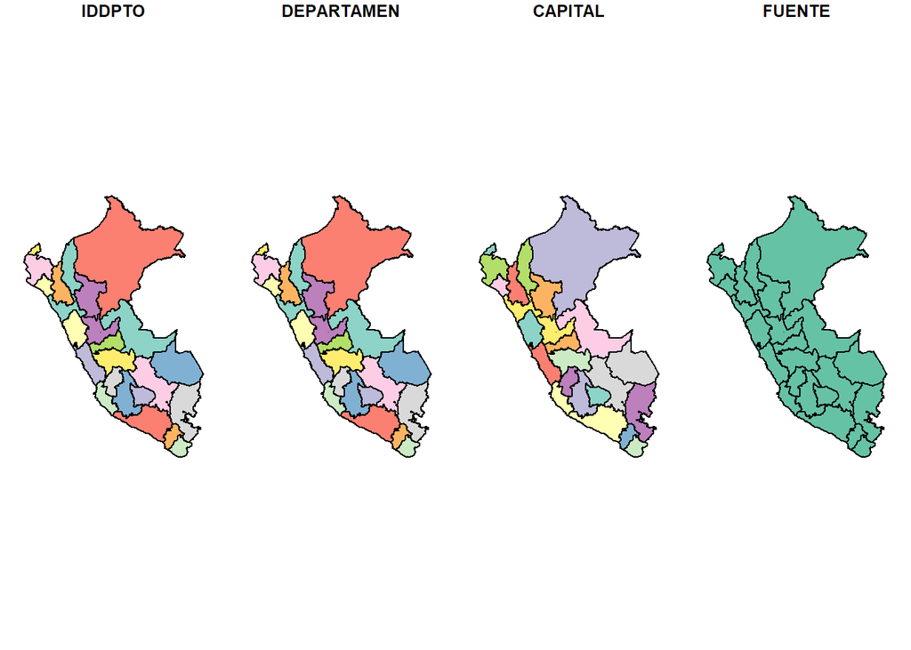

```r
plot(peru)
```

## 6.2 Gráfico avanzado

Para elaborar su primer mapa en R, este tutotial utiliza el paquete `Ggplot2`, tal vez el paquete más utilizado para elaborar gráficos avanzados y de alto impacto. `Ggplot2` construye un gráfico combinando una o varias capas de uno o más conjuntos de datos.

Presentación inicial: División política departamental del Perú.

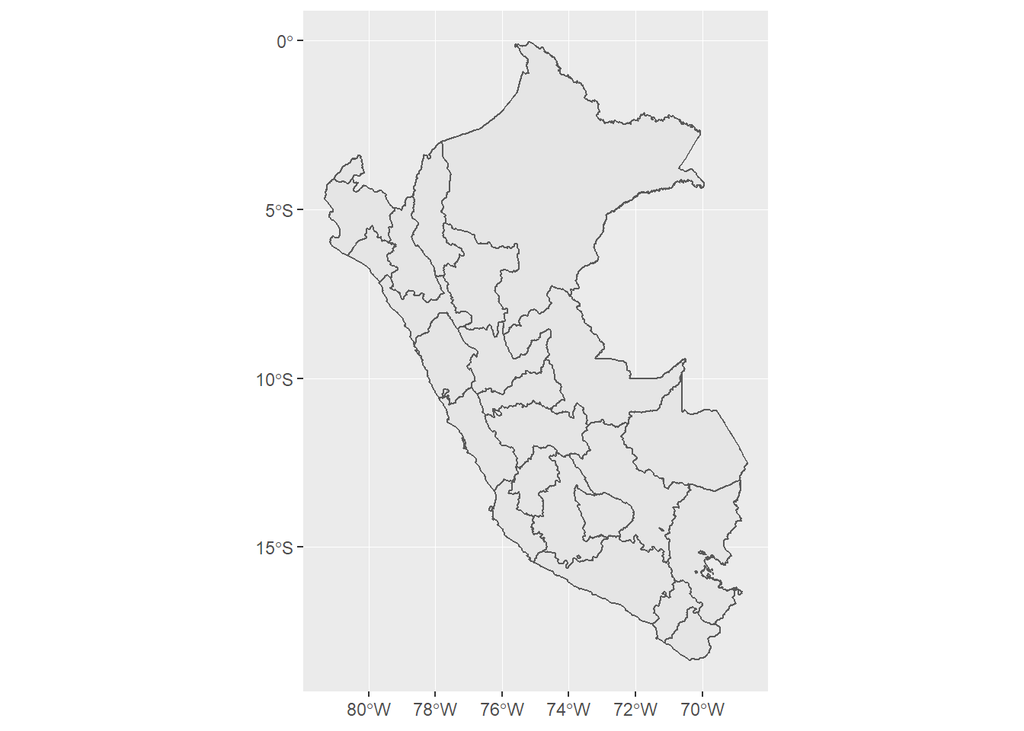

```r
ggplot() +
  geom_sf(data = peru)
```

Mejorar el gráfico incluyendo otros argumentos a la función `geom_sf()`. Para ello, en primer lugar creeamos la función `color()` para darle un poco de color a nuestro mapa.

```r
color = colorRampPalette(c('#01579B','#E1F5FE'))
```

Ahora utilicemos la función `color()` para mejorar el Mapa departamental del Perú.

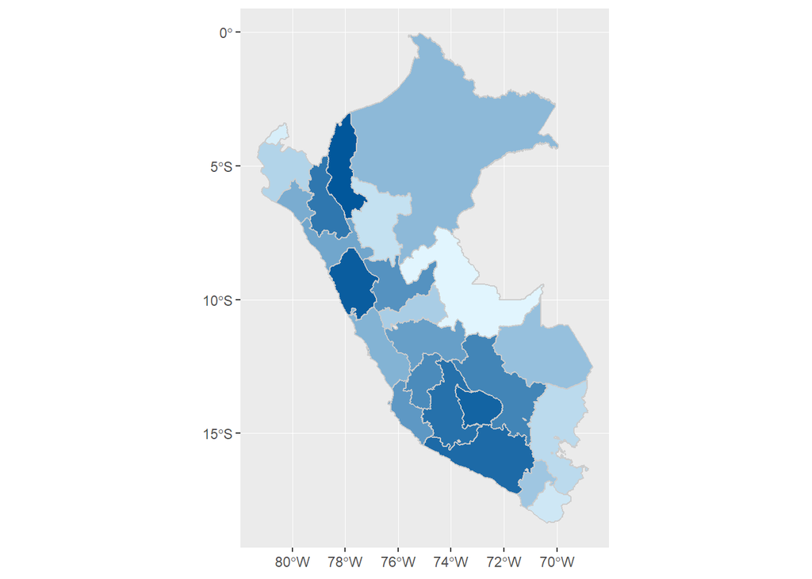

```r
ggplot() +
  geom_sf(data = peru, color = 'grey80', fill = color (25))
```

El comando `fill = color (25)` indica que cada uno de los 25 departamentos del Perú tendrá un color diferente dentro de la rampa de colores creados anteriormente.

A continuación agregamos una capa con los nombres de los departamentos, los cuales se encuentran en la tabla de atributos del *Shapefile*.

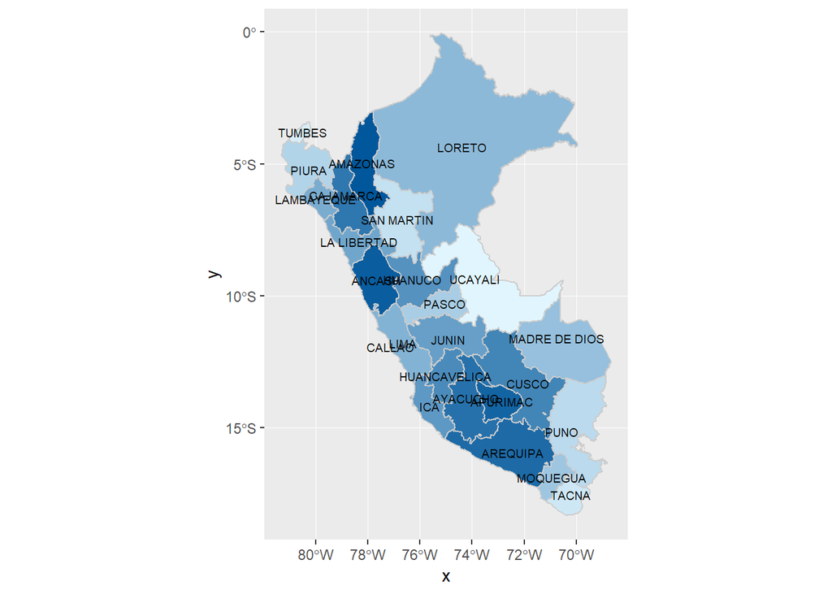

```r
ggplot() +
  geom_sf(data = peru, color = 'grey80', fill = color (25)) +
  geom_sf_text(peru, mapping = aes(label = DEPARTAMEN), colour = "black", size = 2.5)
```

También podemos adicionar un Título para nuestro mapa, así mismo podemos editar el nombre de nuestros “ejes”, que en este caso corresponden a la Longitud (Eje X) y a la Latitud (Eje Y).

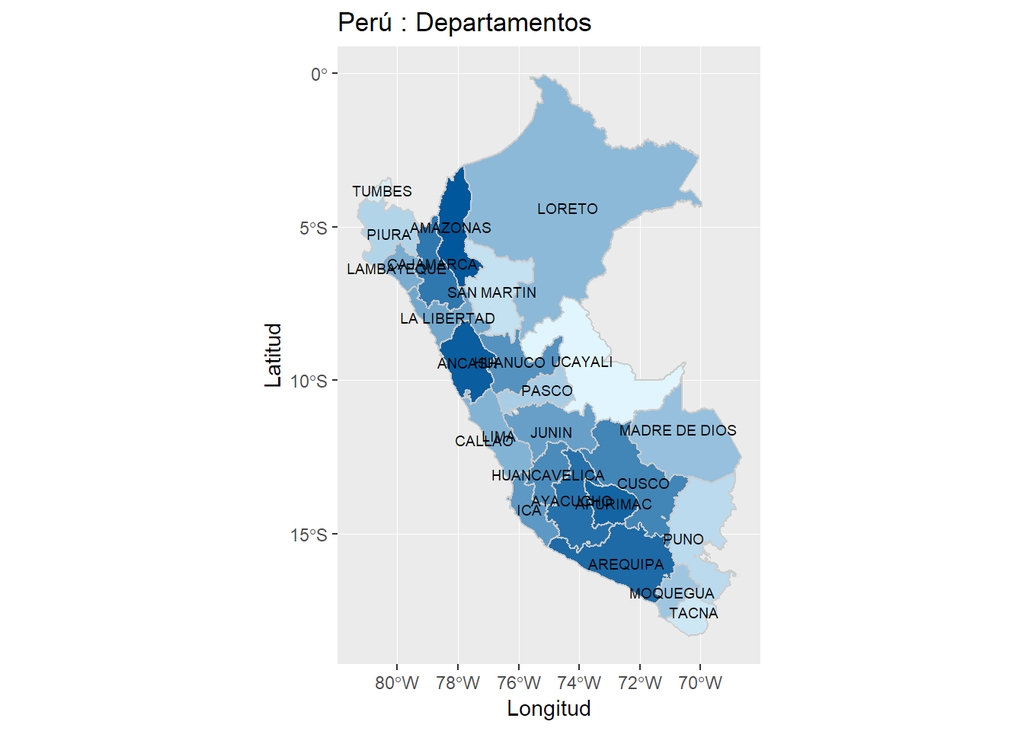

```r
ggplot() +
  geom_sf(data = peru, color = 'grey80', fill = color (25)) +
  geom_sf_text(peru, mapping = aes(label = DEPARTAMEN), colour = "black", size = 2.5) +
  ggtitle('Perú : Departamentos') +
  xlab('Longitud') +
  ylab('Latitud')
```

Si por el contrario se decide no mostrar el nombre de los ejes y sólo los valores de longitud y latitud, simplemente modificamos el Script.

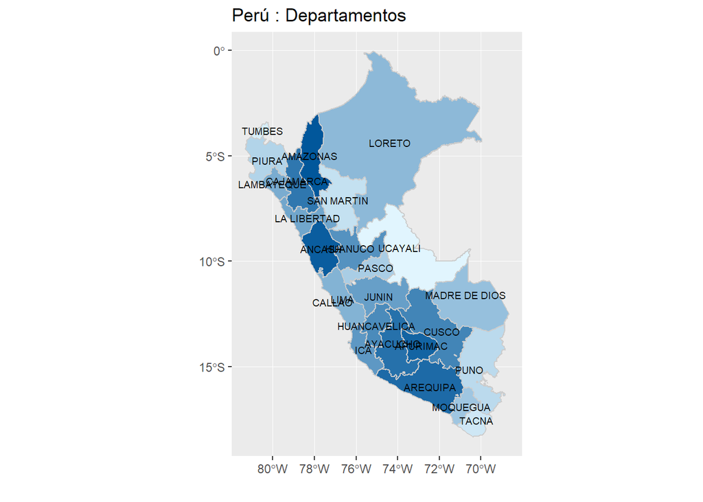

```r
ggplot() +
  geom_sf(data = peru, color = 'grey80', fill = color (25)) +
  geom_sf_text(peru, mapping = aes(label = DEPARTAMEN), colour = "black", size = 2.5) +
  ggtitle('Perú : Departamentos') +
  xlab('') +
  ylab('')
```

Si en lugar de mostrar sólo el mapa departamental, deseamos incluir las capitales departamentales y el nombre de cada capital, entonces adicionamos una capa con los puntos de las capitales de cada departamento, haciendo uso de la función `geom_point()`.

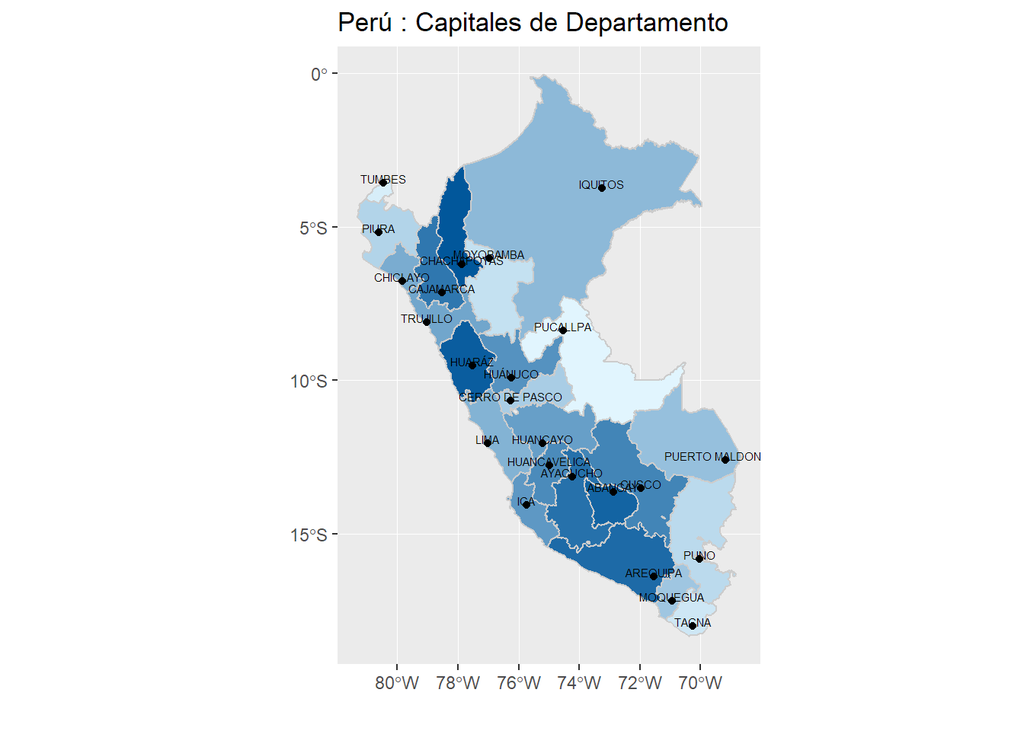

```r
ggplot() +
  geom_sf(data = peru, color = 'grey80', fill = color (25))  +
  geom_point(cap_dep, mapping = aes(x = X, y = Y), shape = 16) +
  geom_sf_text(cap_dep, mapping = aes(label = Nombre),
               colour = "black", size = 2, position = position_nudge(y = 0.15)) +
  ggtitle('Perú : Capitales de Departamento') +
  xlab('') +
  ylab('')
```

Finalmente, adicionaremos el Norte y la Escala gráfica de nuestro Mapa, para ellos se utilizan las funciones `north()` e `scalebar()` del paquete `ggsn`.

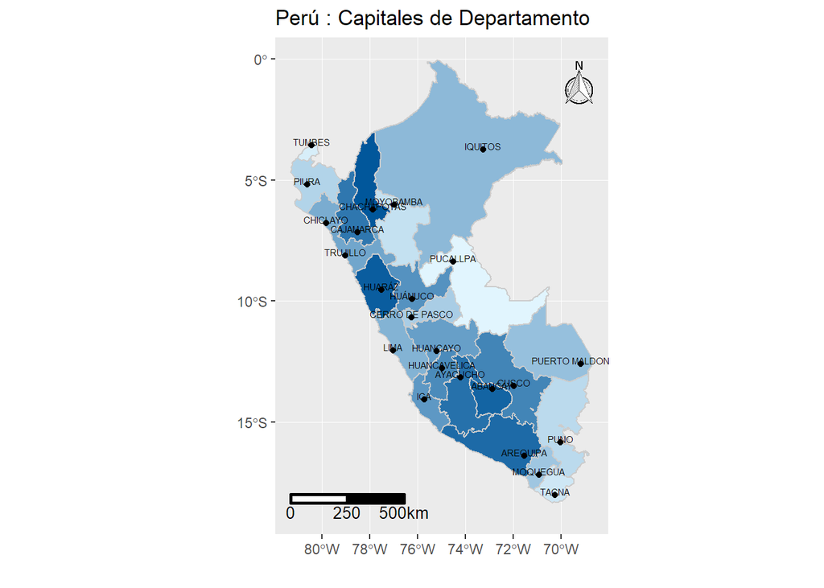

```r
ggplot() +
  geom_sf(data = peru, color = 'grey80', fill = color (25))  +
  geom_point(cap_dep, mapping = aes(x = X, y = Y), shape = 16) +
  geom_sf_text(cap_dep, mapping = aes(label = Nombre),
               colour = "black", size = 2, position = position_nudge(y = 0.15)) +
  ggtitle('Perú : Capitales de Departamento') +
  xlab('') +
  ylab('') +
  north(peru) +
  scalebar(peru, dist = 250, dist_unit = "km",
           transform = TRUE, model = "WGS84",
           st.size = 3.5, location = "bottomleft")
```

# 7 Paso 5

## 7.1 Exportar Mapa en PDF

R ofrece diversas opciones para guardar la información generada. A continuación utilizaremos la funcion `pdf()` para expotar nuestros mapas en un Documento PDF. Para ello, cree una carpeta con el nombre **Mapas** dentro de la carpeta de trabajo matriz (ej. G:/GIS_con_R/Mapas).

```r
pdf("./Mapas/Peru.pdf", width = 8.2, height = 11.7)

ggplot() +
  geom_sf(data = peru, color = 'grey80', fill = color (25))  +
  geom_point(cap_dep, mapping = aes(x = X, y = Y), shape = 16) +
  geom_sf_text(cap_dep, mapping = aes(label = Nombre),
               colour = "black", size = 2, position = position_nudge(y = 0.15)) +
  ggtitle('Perú : Capitales de Departamento') +
  xlab('') +
  ylab('') +
  north(peru) +
  scalebar(peru, dist = 250, dist_unit = "km",
           transform = TRUE, model = "WGS84",
           st.size = 3.5, location = "bottomleft")

dev.off()
```

**Nota**: El primer atritbuto de la función `pdf()` indica el nombre y la ruta donde será guardado el archivo PDF que se va crear, los atributos `width` y `height` indican las dimensiones del gráfico en pulgadas. La función `dev.off` cierra las ventanas gráficas.

**Dónde está el Mapa en PDF?**

Dirijase a la carpeta Mapas dentro de la carpeta matriz de trabajo y verifique que el Archivo **Peru.pdf** haya sido creado.

## 7.2 Bonus: Multiplot en formato JPEG

Ahora vamos a crear un gráfico múltiple en formato **JPEG**, en el que se muestren los mapas presentados al inicio de este Tutorial.

Primero, será necesario ejecutar la función `multiplot()` que se detalla a continuación:

```r
#Funcion para crear un gráfico multiple con ggplot2
{multiplot <- function(..., plotlist=NULL, file, cols=1, layout=NULL) {
  library(grid)
  plots <- c(list(...), plotlist)
  numPlots = length(plots)
  if (is.null(layout)) {
    layout <- matrix(seq(1, cols * ceiling(numPlots/cols)),
                     ncol = cols, nrow = ceiling(numPlots/cols))
  }
  if (numPlots==1) {
    print(plots[[1]])
  } else {
    grid.newpage()
    pushViewport(viewport(layout = grid.layout(nrow(layout), ncol(layout))))
    for (i in 1:numPlots) {
      matchidx <- as.data.frame(which(layout == i, arr.ind = TRUE))
      print(plots[[i]], vp = viewport(layout.pos.row = matchidx$row,
                                      layout.pos.col = matchidx$col))
    }
  }
}
}
```

Seguidamente, creamos dos objetos a los cuales le asignaremos cada uno de los mapas creados anteriormente:

```r
#Objeto p1 para almacenar el mapa de los departamentos del Perú
p1 <- ggplot() +
  geom_sf(data = peru, color = 'grey80', fill = color (25))  +
  geom_sf_text(peru, mapping = aes(label = DEPARTAMEN), colour = "black", size = 2.5) +
  ggtitle('Perú : Departamentos') +
  xlab('') +
  ylab('') +
  coord_sf() +
  north(peru) +
  scalebar(peru, dist = 250, dist_unit = "km",
           transform = TRUE, model = "WGS84",
           st.size = 3.5, location = "bottomleft")

#Crea una rampa de color diferente para el segundo Mapa.
color = colorRampPalette(c('darkolivegreen1','springgreen', 'royalblue'))


#Objeto p2 para almacenar el mapa de los departamentos del Perú y sus respectivas capitales
p2 <- ggplot() +
  geom_sf(data = peru, color = 'darkolivegreen', fill = color (25))  +
  geom_point(cap_dep, mapping = aes(x = X, y = Y),
             shape = 21, fill= 'khaki1', color= 'black', size=1.5) +
  geom_sf_text(cap_dep, mapping = aes(label = Nombre),
               colour = "black", size = 2, position = position_nudge(y = 0.2)) +
  ggtitle('Perú : Capitales de Departamento') +
  xlab('') +
  ylab('') +
  north(peru) +
  scalebar(peru, dist = 250, dist_unit = "km",
           transform = TRUE, model = "WGS84",
           st.size = 3.5, location = "bottomleft")
```

Como puede observar, ninguno de los dos gráficos fueron generados todavía. Aqui utilizaremos la función `multiplot()` para generar un gráfico múltiple y la función `jpeg()` para guardar dicho gráfico en formato **JPEG**.

```r
#Mapa en JPEG
jpeg("./Mapas/Peru2.jpeg", width = 2362, height = 1654,
     units = "px", pointsize =12, bg = "white",
     res = 300, restoreConsole = TRUE)
multiplot(p1, p2, cols = 2)
dev.off()
```

Verifique que el Archivo **Peru2.jpeg** dentro de la carpeta Mapas haya sido creado.

Su mapa devería verse así:

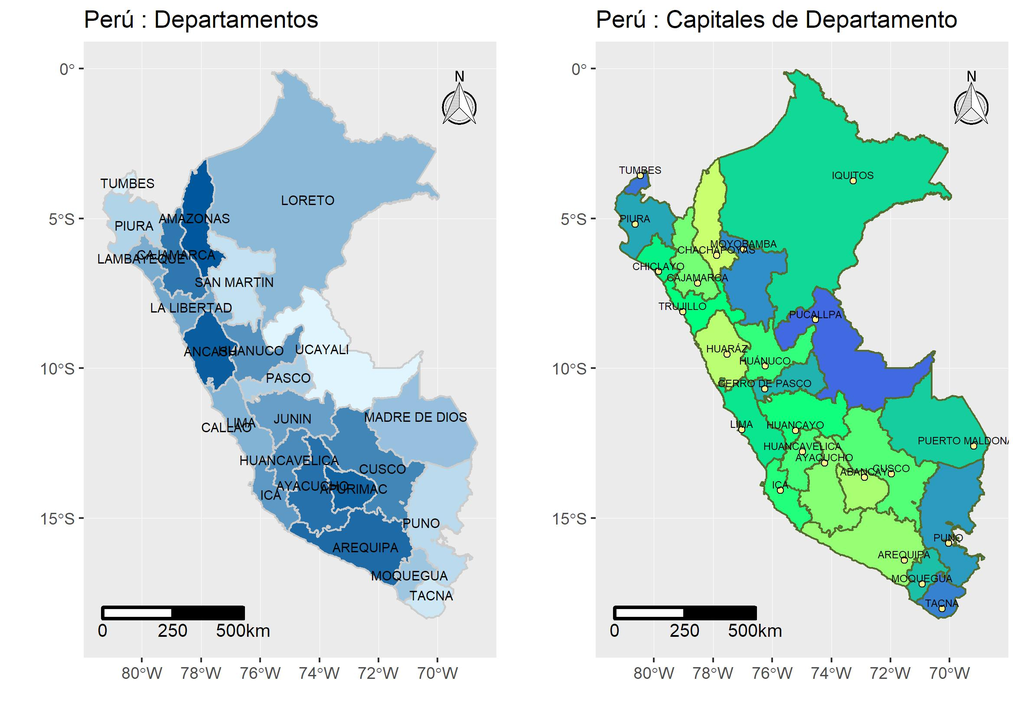

Si todo salió bien hasta aquí

**Felicitaciones !!!**

Creaste tus primeros mapas utilizando R.  
**CONTACTO**

M.Sc. Duberlí Elera Gonzáles  
Docente en la [Universidad Cientifica del Sur](https://www.cientifica.edu.pe/)  
Especialista Forestal en [Diamante Verde SRL](https://www.diamanteverdesrl.com/)  
Email: duberelera@gmail.com  
+51 986 626 642